# R Notebook

[figure not shown]

```r
knitr::opts_chunk$set(dev.args = list(png = list(type = "cairo")))
require(xml2)
library(tidyverse)
library(lubridate)
library(rvest)
```

First we will read in the SVG file as XML and look at the straight lines - i.e. the axis plots and so on.

```r
theme_set(theme_classic())

doc <- read_xml("ons_scatterplot.svg") %>% xml_ns_strip()
lines <- xml_nodes(doc, "line")

linesdf <-
  tibble(bind_rows(lapply(xml_attrs(lines), as.data.frame.list))) %>%
  mutate_at(c("x1", "x2", "y1", "y2"), as.character) %>%
  mutate_at(c("x1", "x2", "y1", "y2"), as.numeric) %>%
  mutate(y1 = -y1, y2 = -y2) %>%
  mutate(length = sqrt((x2 - x1)^2 + (y2 - y1)^2))
```

Let’s try drawing this set of lines.

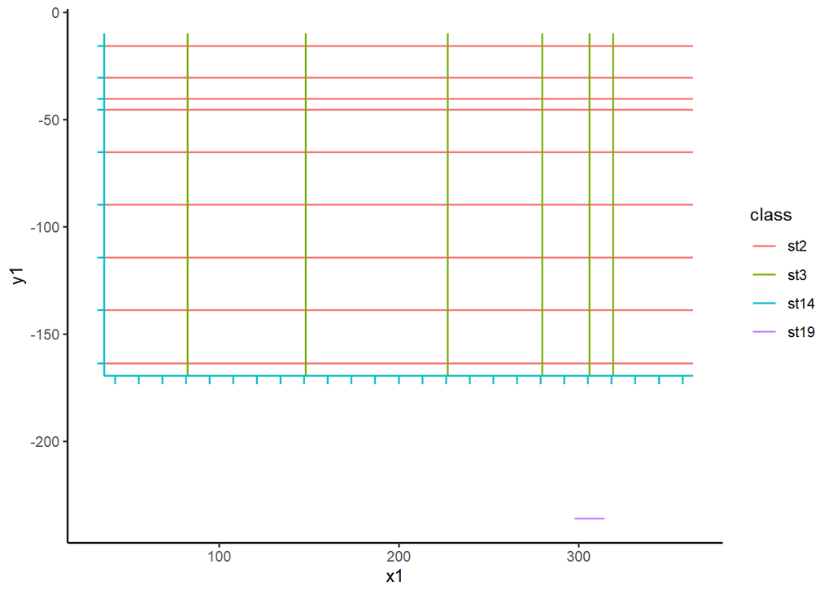

```r
ggplot(linesdf, aes(x = x1, xend = x2, y = y1, yend = y2, color = class)) +
  geom_segment()
```

OK, so `st14` represents the black lines of the axis - lets extract those some more and mark them as horizontal or vertical.

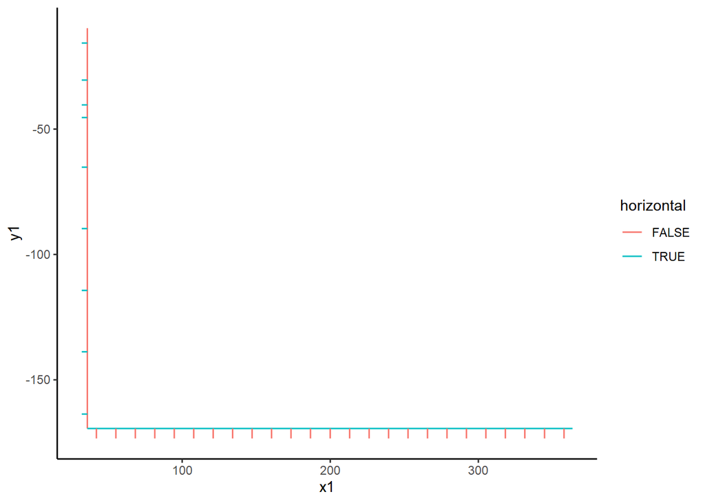

```r
black_lines <- linesdf %>%
  filter(class == "st14") %>%
  mutate(horizontal = abs(y2 - y1) < 10 * abs(x2 - x1)) %>%
  mutate(vertical = !horizontal)

ggplot(black_lines, aes(x = x1, xend = x2, y = y1, yend = y2, color = horizontal)) +
  geom_segment()
```

We can also look at the distribution of line lengths to be able to separate out the short ‘ticks’.

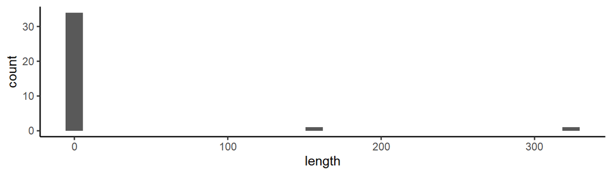

```r
ggplot(black_lines, aes(x = length)) +
  geom_histogram()
```

It looks like any line with length less than 30 will be a tick.

```r
ticks <- black_lines %>%
  mutate(is_tick = length < 30) %>%
  filter(is_tick)
horiz_limits <- ticks %>%
  filter(horizontal) %>%
  filter(y1 == max(y1) | y1 == min(y1))
vert_limits <- ticks %>%
  filter(vertical) %>%
  filter(x1 == max(x1) | x1 == min(x1))


#ggplot(bind_rows(horiz_limits, vert_limits), aes(x = x1, xend = x2, y = y1, yend = y2, color = horizontal)) +
#  geom_segment()
```

Now we can extract the positions of the maximum and minimum tick for each axis, and manually write in the real values those correspond to from the label:

```r
x_min_svg <- min(vert_limits$x1)
x_max_svg <- max(vert_limits$x1)
y_min_svg <- min(horiz_limits$y1)
y_max_svg <- max(horiz_limits$y1)

x_min_real <- ymd("2020-04-26")
x_max_real <- ymd("2020-10-11")
y_min_real <- 10
y_max_real <- 40
```

We’ve dealt with the axes. Now time to move onto the points. Unfortunately they are not points, they are paths (bezier-curves), drawing circles to represent points!

Here is a [useful tool for interpreting SVG commands](https://svg-path-visualizer.netlify.app/)

We’ll extract all the paths

```r
paths <- xml_nodes(doc, "path")
```

And then try to split up the bezier curves into sub commands, like `M` (move to a point), `C` draw a curve in absolute coordinates, `c` draw a curve in relative coordinates, and so on.

```r
pathsdf <-
  tibble(bind_rows(lapply(xml_attrs(paths), as.data.frame.list))) %>%
  mutate(id = 1:n()) %>%
  mutate(d = gsub("S", "|S", d)) %>%
  mutate(d = gsub("s", "|s", d)) %>%
  mutate(d = gsub("z", "|z", d)) %>%
  mutate(d = gsub("c", "|c:", d)) %>%
  mutate(d = gsub("C", "|C:", d)) %>%
  mutate(d = gsub("M", "M:", d)) %>%
  mutate(d = gsub("\n", "", d)) %>%
  mutate(d = gsub(" ", "", d)) %>%
  mutate(d = gsub("([0-9])-", "\\1,-", d))



commandsdf <- pathsdf %>%
  separate_rows(d, sep = "\\|") %>%
  filter(d != "z") %>%
  separate(d, into = c("command", "parameters"), ":")
commandsdf %>%
  group_by(id, command) %>%
  summarise(n = n()) %>%
  group_by(n, command) %>%
  summarise(count = n())
```

| n | command | count |
| --- | --- | --- |
| 1 | C | 3784 |
| 1 | M | 3796 |
| 1 | s-0.72,0.36,-0.72,0.72 | 2 |
| 1 | s-0.72,0.36,-0.72,0.9 | 4 |
| 1 | S43,38.37,43,38.91 | 2 |
| 1 | S43,54.21,43,54.75 | 2 |
| 1 | S43,75.45,43,75.99 | 2 |
| 1 | S44.44,39.27,44.44,38.91 | 2 |
| 1 | S44.44,55.29,44.44,54.75 | 2 |
| 1 | S44.44,76.53,44.44,75.99 | 2 |

[output cut: 5 more lines]

```r
commands_processed <- commandsdf %>%
  separate(parameters, into = c("p1", "p2", "p3", "p4", "p5", "p6"), sep = ",") %>%
  mutate(abs_x = case_when(command == "M" ~ p1, command == "C" ~ p5), abs_y = case_when(command == "M" ~ p2, command == "C" ~ p6)) %>%
  mutate(rel_x = case_when(command == "c" ~ p5), rel_y = case_when(command == "c" ~ p6))
```

These circles are represented as 4 curves, with 4 control points. If we take the average of these we can find the position of the point. One of the points in just the `M` coordinates, but 3 are from `c` commands, and they only have relative coordinates, so we need to calculate the cumulative sums of these, and then add them to the `M` coordinates. Then we average out, and add back the class metadata.

```r
lowercase_cs <- commands_processed %>%
  group_by(id) %>%
  filter(command == "c") %>%
  mutate(rel_x_sum = cumsum(rel_x), rel_y_sum = cumsum(rel_y)) %>%
  select(id, rel_x_sum, rel_y_sum)

zeroes <- lowercase_cs %>%
  group_by(id) %>%
  summarise(rel_x_sum = 0, rel_y_sum = 0)
full_relative_set <- bind_rows(lowercase_cs, zeroes)

uppercase_cs <- commands_processed %>%
  filter(command == "C") %>%
  select(id, command, abs_x, abs_y) %>%
  mutate(abs_x = as.numeric(abs_x), abs_y = as.numeric(abs_y))

both <- inner_join(uppercase_cs, full_relative_set, by = "id") %>% mutate(x = abs_x + rel_x_sum, y = abs_y + rel_y_sum)

point_types <- pathsdf %>% select(id, class)

points <- both %>%
  group_by(id) %>%
  summarise(x = mean(x), y = mean(y)) %>%
  inner_join(point_types, by = "id") %>%
  mutate(y = -y) %>%
  filter(class %in% c("st10", "st7", "st9", "st12", "st11", "st5"))
```

Above you can see I have filtered to only some of the classes. This is because some points were represented by two curves, one a stroke and one a fill. Now let’s plot the points.

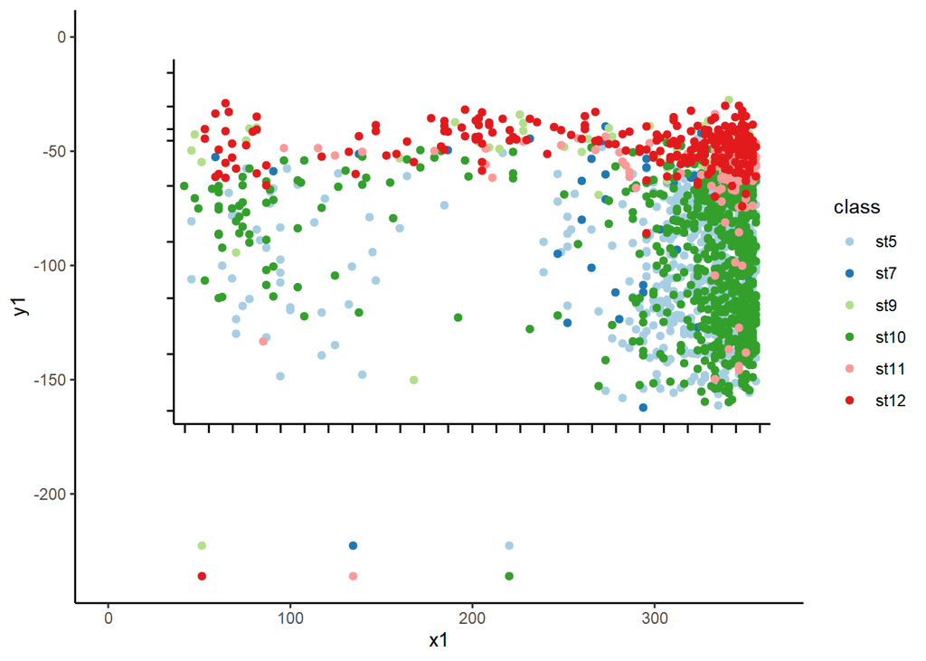

```r
ggplot(black_lines, aes(x = x1, xend = x2, y = y1, yend = y2)) +
  geom_segment() +
  geom_point(data = points %>% mutate(x2 = 0, y2 = 0), aes(x = x, y = y, color = class)) +
  scale_color_brewer(type = "qual", palette = "Paired")
```

Conveniently, the points in the key are still there, so we can easily label these classes with their correct metadata

```r
genes_detected <- c(1, 1, 2, 2, 3, 3)
symptoms <- c("yes", "no", "yes", "no", "yes", "no")
classes <- c("st9", "st12", "st7", "st11", "st5", "st10")

class_info <- tibble(class = classes, symptoms = symptoms, genes_detected = genes_detected)


points_detail <- points %>%
  inner_join(class_info) %>%
  mutate(genes_detected = as.factor(genes_detected))
```

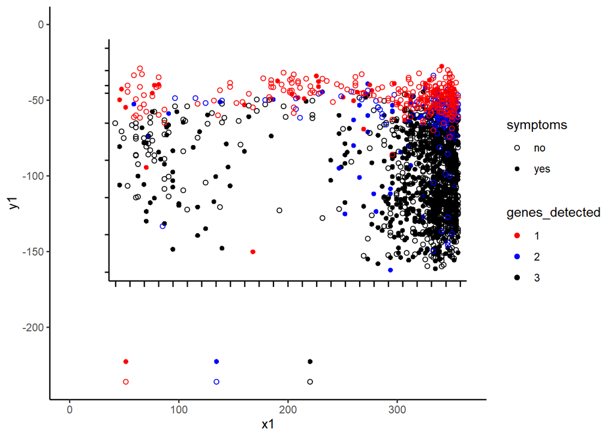

```r
ggplot(black_lines, aes(x = x1, xend = x2, y = y1, yend = y2)) +
  geom_segment() +
  geom_point(data = points_detail %>% mutate(x2 = 0, y2 = 0), aes(x = x, y = y, color = genes_detected, shape = symptoms)) +
  scale_color_manual(values = c("red", "blue", "black"))+scale_shape_manual(values=c(1,16))
```

Getting there!

Now we just need to transform ourselves into the right axes:

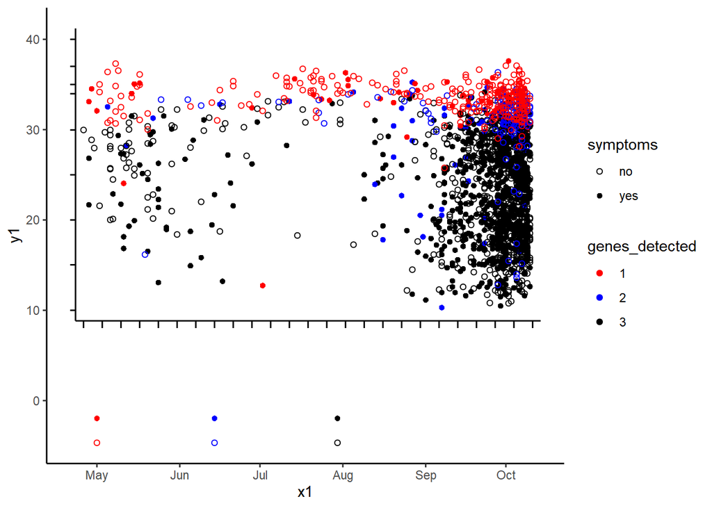

```r
transform <- function(vector, a_in, a_out, b_in, b_out) {
  scaling <- (b_out - a_out) / (b_in - a_in)
  vector <- (vector - a_in) * scaling + a_out
  return(vector)
}


ytransform <- partial(transform, a_in = y_min_svg, a_out = y_min_real, b_in = y_max_svg, b_out = y_max_real)
xtransform <- partial(transform, a_in = x_min_svg, a_out = x_min_real, b_in = x_max_svg, b_out = x_max_real)


new_axes <- black_lines %>% mutate(y1 = ytransform(y1), y2 = ytransform(y2), x1 = xtransform(x1), x2 = xtransform(x2))

points_transformed <- points_detail %>% mutate(y = ytransform(y), x = xtransform(x))


ggplot(new_axes, ) +
  geom_segment(aes(x = x1, xend = x2, y = y1, yend = y2)) +
  geom_point(data = points_transformed %>% mutate(x2 = ymd("2020-01-01"), y2 = ymd("2020-01-01")), aes(x = x, y = y, color = genes_detected, shape = symptoms)) +
  scale_color_manual(values = c("red", "blue", "black"))+scale_shape_manual(values=c(1,16))
```

OK, at this point we can throw away the axes and just focus on the points.

```r
values <- points_transformed %>%
  filter(y > 0) %>%
  mutate(Date = x, Ct = y) %>%
  select(-x, -y, -class,-id)

write_csv(values, "extracted_ct_value_genes_detected_and_symptoms.csv")
values
```

| symptoms | genes_detected | Date | Ct |
| --- | --- | --- | --- |
| yes | 3 | 2020-04-28 | 26.82482 |
| yes | 3 | 2020-04-28 | 21.67883 |
| yes | 3 | 2020-05-07 | 22.88321 |
| yes | 3 | 2020-05-09 | 29.35219 |
| yes | 3 | 2020-05-10 | 21.75182 |
| yes | 3 | 2020-05-10 | 27.33577 |
| yes | 3 | 2020-05-11 | 18.13869 |
| yes | 3 | 2020-05-11 | 16.84307 |
| yes | 3 | 2020-05-11 | 27.33577 |
| yes | 3 | 2020-05-13 | 19.30657 |

[output cut: 1876 more lines]

And there’s our dataset.

And here’s our graph

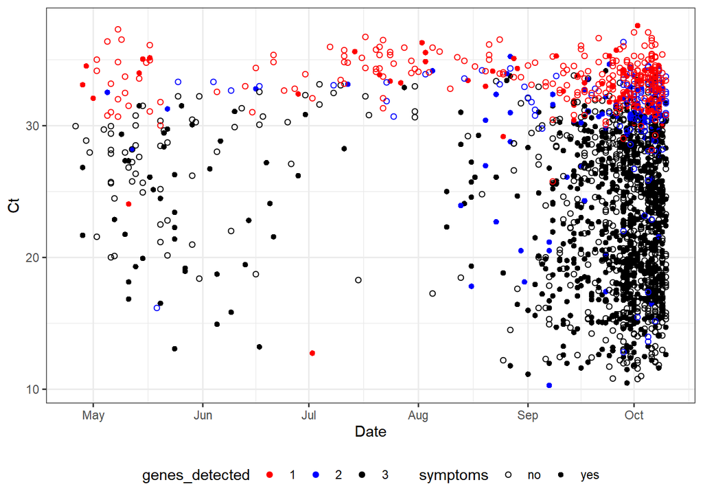

```r
ggplot(values,aes(x=Date,y=Ct,color=genes_detected,shape=symptoms)) +
  scale_color_manual(values = c("red", "blue", "black"))+scale_shape_manual(values=c(1,16)) +geom_point()+theme_bw()+ theme(legend.position="bottom")
```

as compared to

[figure not shown]

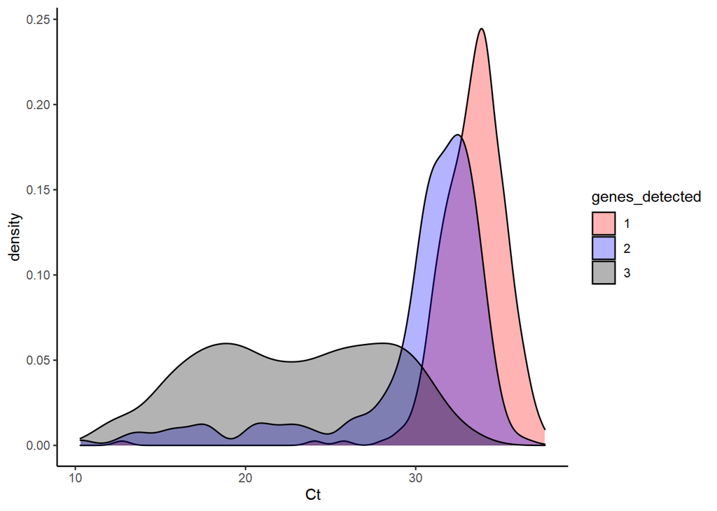

```r
ggplot(values,aes(x=Ct,fill=genes_detected)) +
  scale_fill_manual(values = c("red", "blue", "black")) +geom_density(alpha=0.3)
```

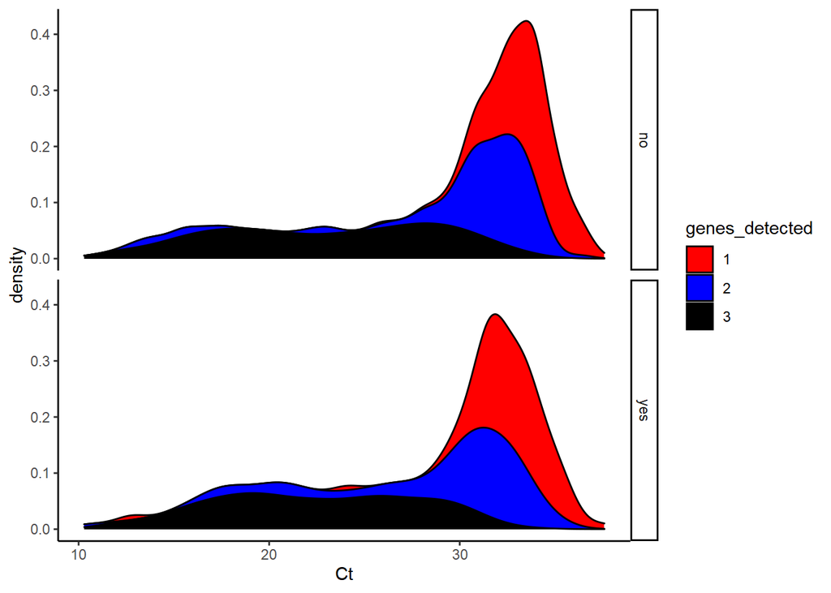

```r
ggplot(values,aes(x=Ct,fill=genes_detected)) +
  scale_fill_manual(values = c("red", "blue", "black")) +geom_density(position="stack")+facet_grid(symptoms~.)
```

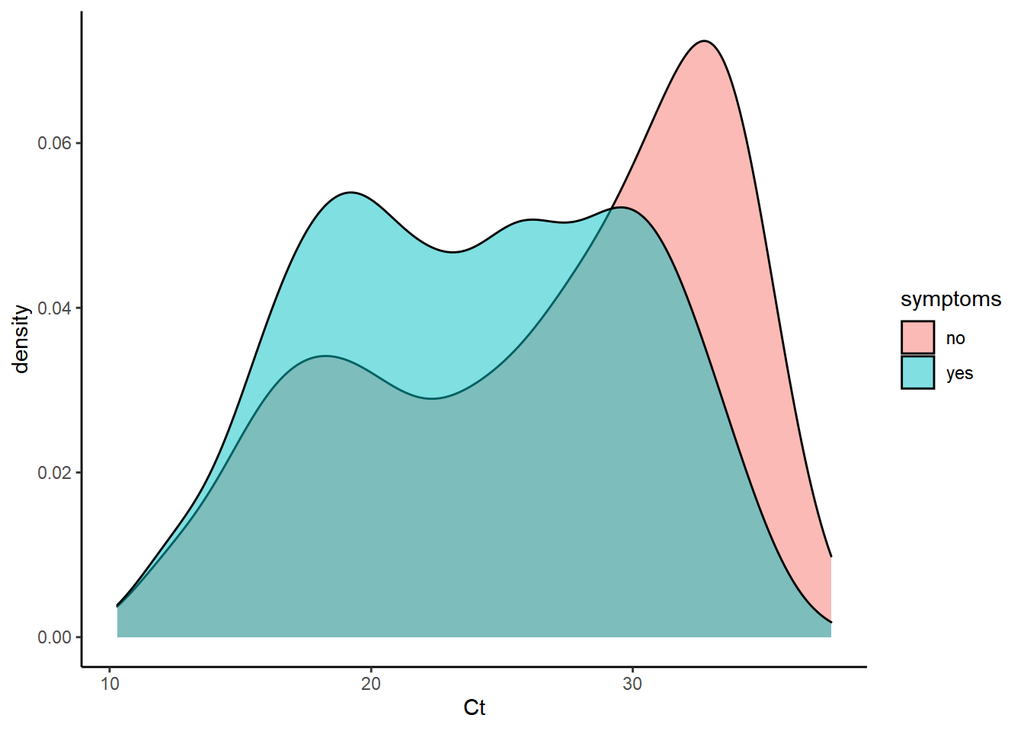

```r
ggplot(values,aes(x=Ct,fill=symptoms)) + geom_density(alpha=0.5)
```

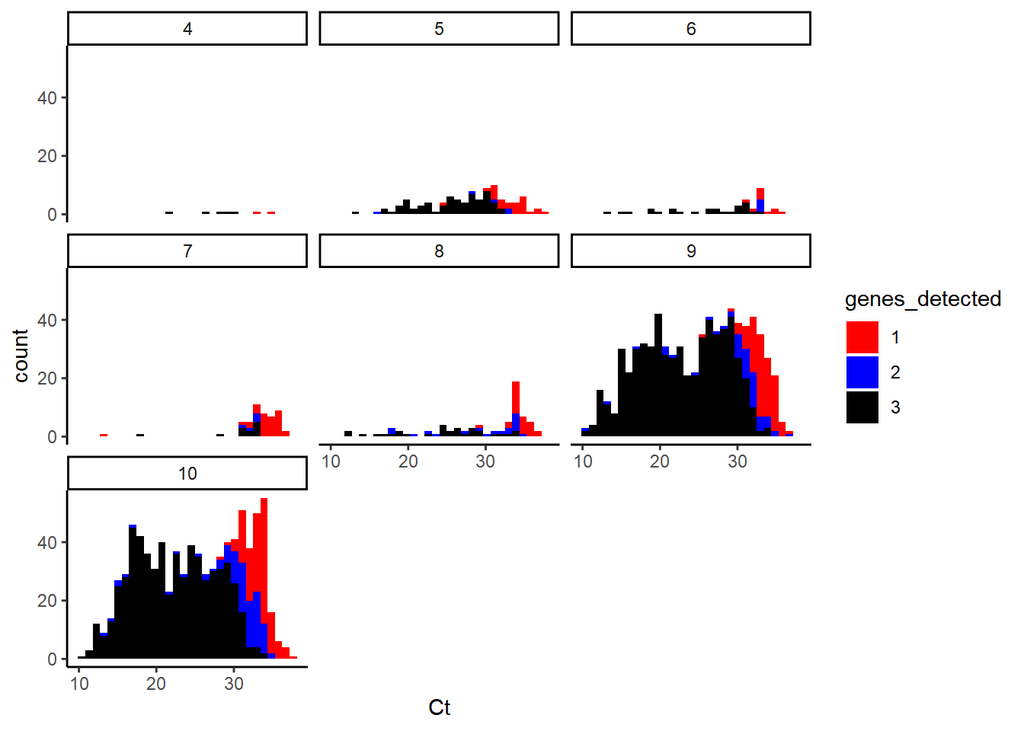

```r
ggplot(values,aes(x=Ct,fill=genes_detected)) +
  scale_fill_manual(values = c("red", "blue", "black")) +geom_histogram() +facet_wrap(~month(Date))
```

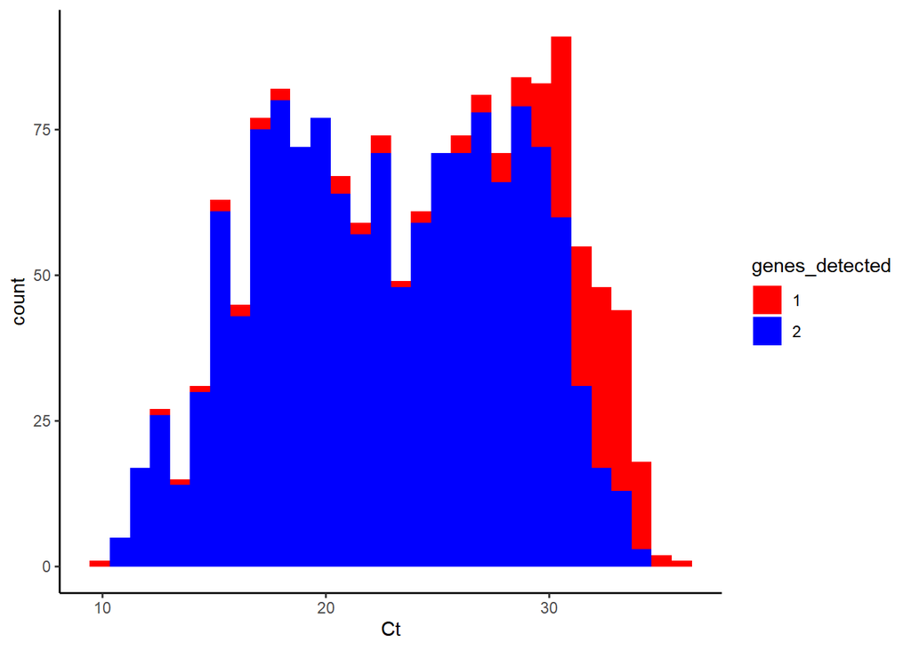

```r
simulated_b117 = values %>% mutate(genes_detected=as.factor(as.numeric(as.character(genes_detected))-1)) %>% filter(genes_detected!= 0)
ggplot(simulated_b117,aes(x=Ct,fill=genes_detected)) +
  scale_fill_manual(values = c("red", "blue", "black")) +geom_histogram()
```